# HW 3

due 3/22/23

Author

Ava Waters

Published

March 1, 2023

Please remember that this homework is to be done individually!

**Look at `hw3_instructions.html` for more information on the two data sets and for helpful hints throughout.**

```r
#Load R packages here
library(reticulate)
library(tidyverse)
```

```python
# import necessary python packages here
import pandas as pd
import numpy as np
import matplotlib.pyplot as plt
import seaborn as sns
from sklearn.preprocessing import StandardScaler, OneHotEncoder
from sklearn.pipeline import Pipeline
from sklearn.compose import make_column_transformer
from sklearn.linear_model import LinearRegression
from sklearn.model_selection import cross_val_predict, train_test_split
from sklearn.model_selection import GroupKFold, cross_val_score
from sklearn.metrics import mean_squared_error, r2_score
from sklearn.linear_model import Ridge, RidgeCV, Lasso, LassoCV, ElasticNetCV
from sklearn.datasets import make_regression
```

# Part 1: Regularization with Correlated Predictors

## Simulating Data

```r
set.seed(1966) # World Cup in England, won (robbed?) by England against Germany

# number of observations
n <- 1000
p_uninformative <- 5

# simulate informative predictors
x1 <- rnorm(n, mean = 5, sd = 1.5)
x2 <- rpois(n, lambda = abs(x1 + 10))
x3 <- x1 + 1.25 * x2 + rnorm(n, mean = 1, sd = 1)
x4 <- 20 * rbeta(n, shape1 = 2, shape2 = 3)
x5 <- -1 * sample(c(-1, 0, 1), size = n,
                  prob = c(1/6, 1/6, 2/3),
                  replace = TRUE) * rgamma(n, shape = 1, rate = 5)

# binding informative xs together
X_inform <- cbind(x1, x2, x3, x4, x5)
colnames(X_inform) <- paste0("x", 1:5)

# true betas
betas <- c(0.5, 0.15, 0.35, 1.33, -10)
# true beta * sd = true beta for scaled variables
standardized_betas <- betas * apply(X_inform, MARGIN = 2, FUN = sd)

# simulate y
y <- X_inform %*% betas + #systematic component
  rnorm(n, mean = 0, 4) # stochastic component

# simulating 5 *un*informative predictors
X_uninform <- matrix(rnorm(n * p_uninformative, mean = 2, sd = 2),
                 ncol = p_uninformative, nrow = n,
                 dimnames = list(NULL, paste0("x", 6:(5 + p_uninformative))))

# putting all together into a data set
data_sim <- data.frame(y = y, X_inform, X_uninform)

# making entire coefficient vector (including noninformative Xs)
all_betas <- c(standardized_betas, rep(0, times = p_uninformative))
```

```python
data_sim = r.data_sim
all_betas = r.all_betas
```

## Q1

```python
# glimpse at data_sim
data_sim.head()

# informative predictors
```

```
           y        x1    x2         x3  ...        x7        x8        x9       x10
0  20.409335  6.412898  10.0  18.396999  ...  4.834014  2.079288  1.174105  3.198592
1  14.858964  2.633696   9.0  16.419955  ...  1.442229  0.301404  5.619488  6.433048
2  23.092782  2.342432  22.0  29.906989  ...  1.038059  3.577298  2.543055  1.799628
3  25.311482  4.908888  11.0  18.953887  ... -1.641611  3.447655  3.176912  4.497459
4   9.373324  2.465711  18.0  25.468474  ...  2.527838  4.896207  2.741548  0.478385

[5 rows x 11 columns]
```

```python
pred_inf = ["x1", "x2", "x3", "x4", "x5"]

for pred in pred_inf:
  # np.corrcoef returns a matrix, i am saving only the value of interest
  corr = np.corrcoef(data_sim[pred], data_sim["y"], rowvar=False)[0][1]
  # calc and print r (correlation)
  print("predictor " + pred + " correlation: " + str(corr))
```

```
predictor x1 correlation: 0.2733641196454568
predictor x2 correlation: 0.3824081820820748
predictor x3 correlation: 0.4156045130476465
predictor x4 correlation: 0.6785072496567177
predictor x5 correlation: -0.2393858517709034
```

The two variables that have the strongest correlation are x4 and x3. The correlation between x4 and y is 0.6785, and the correlation between x3 and y is 0.4156.

## Q2

```python
# function that takes a transformer and a model instantiator
# and returns a pipeline with two components:
# the transformer called "preprocess" and the model called "model"
def make_pipe(transformer, mod_inst):
  pipeline = Pipeline([('preprocess', transformer),
                       ('model', mod_inst)])

  return pipeline
```

## Q3

```python
# make data frame with only the features
X = data_sim.drop(["y"], axis=1)

# series with outcome var
y = data_sim["y"]
```

## Q4

```python
# make preprocessor
preprocessor = make_column_transformer((StandardScaler(), X.columns),
               verbose_feature_names_out=False)
```

## Q5

```python
# train / validation set split
X_train, X_test, y_train, y_test = train_test_split(
  X, y, random_state = 1954)
```

## Q6

```python
# linear regression model
pipeline_lr = make_pipe(preprocessor, LinearRegression())
pipeline_lr.fit(X_train, y_train)

# Ridge model
```

```
Pipeline(steps=[('preprocess',
                 ColumnTransformer(transformers=[('standardscaler',
                                                  StandardScaler(),
                                                  Index(['x1', 'x2', 'x3', 'x4', 'x5', 'x6', 'x7', 'x8', 'x9', 'x10'], dtype='object'))],
                                   verbose_feature_names_out=False)),
                ('model', LinearRegression())])
```

```python
pipeline_ridge = make_pipe(preprocessor, RidgeCV(alphas = np.logspace(-5, 5, 100), store_cv_values = True))
pipeline_ridge.fit(X_train, y_train)

# LASSO model
```

```
Pipeline(steps=[('preprocess',
                 ColumnTransformer(transformers=[('standardscaler',
                                                  StandardScaler(),
                                                  Index(['x1', 'x2', 'x3', 'x4', 'x5', 'x6', 'x7', 'x8', 'x9', 'x10'], dtype='object'))],
                                   verbose_feature_names_out=False)),
                ('model',
                 RidgeCV(alphas=array([1.00000000e-05, 1.26185688e-05, 1.59228279e-05, 2.00923300e-05,
       2.53536449e-05, 3.19926714e-05, 4.03701726e-05, 5.0941...
       4.75081016e+02, 5.99484250e+02, 7.56463328e+02, 9.54548457e+02,
       1.20450354e+03, 1.51991108e+03, 1.91791026e+03, 2.42012826e+03,
       3.05385551e+03, 3.85352859e+03, 4.86260158e+03, 6.13590727e+03,
       7.74263683e+03, 9.77009957e+03, 1.23284674e+04, 1.55567614e+04,
       1.96304065e+04, 2.47707636e+04, 3.12571585e+04, 3.94420606e+04,
       4.97702356e+04, 6.28029144e+04, 7.92482898e+04, 1.00000000e+05]),
                         store_cv_values=True))])
```

```python
pipeline_lasso = make_pipe(preprocessor, LassoCV(alphas = np.logspace(-5, 5, 100)))
pipeline_lasso.fit(X_train, y_train)
```

```
Pipeline(steps=[('preprocess',
                 ColumnTransformer(transformers=[('standardscaler',
                                                  StandardScaler(),
                                                  Index(['x1', 'x2', 'x3', 'x4', 'x5', 'x6', 'x7', 'x8', 'x9', 'x10'], dtype='object'))],
                                   verbose_feature_names_out=False)),
                ('model',
                 LassoCV(alphas=array([1.00000000e-05, 1.26185688e-05, 1.59228279e-05, 2.00923300e-05,
       2.53536449e-05, 3.19926714e-05, 4.03701726e-05, 5.0941...
       4.75081016e+02, 5.99484250e+02, 7.56463328e+02, 9.54548457e+02,
       1.20450354e+03, 1.51991108e+03, 1.91791026e+03, 2.42012826e+03,
       3.05385551e+03, 3.85352859e+03, 4.86260158e+03, 6.13590727e+03,
       7.74263683e+03, 9.77009957e+03, 1.23284674e+04, 1.55567614e+04,
       1.96304065e+04, 2.47707636e+04, 3.12571585e+04, 3.94420606e+04,
       4.97702356e+04, 6.28029144e+04, 7.92482898e+04, 1.00000000e+05])))])
```

## Q7

```python
# save optimal alphas
ridge_alpha = pipeline_ridge["model"].alpha_
lasso_alpha = pipeline_lasso["model"].alpha_
```

The optimal alpha found via CV for the Ridge model is 4.5348785.

The optimal alpha found via CV for the LASSO model is 0.0869749.

## Q8

```python
# create a data frame with betas
# all_betas has real beta values
# .coef_ attribute of models gets beta estimates
betas = pd.DataFrame(list(zip(all_betas, pipeline_lr["model"].coef_, pipeline_ridge["model"].coef_, pipeline_lasso["model"].coef_)), columns = ["true_coef", "linear", "Ridge", "LASSO"])

betas
```

```
   true_coef    linear     Ridge     LASSO
0   0.758008  0.360323  0.471350  0.273609
1   0.620909  0.141990  0.514088  0.000000
2   2.079794  3.028725  2.592581  3.127140
3   5.310241  5.375224  5.342872  5.275064
4  -2.299765 -2.086533 -2.069973 -1.989325
5   0.000000  0.126873  0.123351  0.021779
6   0.000000  0.052999  0.051231  0.000000
7   0.000000 -0.018225 -0.023985 -0.000000
8   0.000000 -0.087058 -0.088870 -0.000000
9   0.000000  0.001455  0.000354 -0.000000
```

The LASSO has shrunken some predictors. It shrank the beta associated with x2, even though it is informative. It also failed to shrink the beta for x6, which we know is an uninformative predictor. The model did this to only include the features it thinks are helpful in predicting y. This complicates our ability to infer causality using the LASSO model. Because it gives weight to a beta we know doesn’t have any relationship to the outcome variable, we know we cannot conclude causality. Because it excludes a feature we know is informative of the outcome variable, we know any causality it does predict is not completely accurate.

## Q9

```python
# predict y values
ridge_y_pred = pipeline_ridge.predict(X_test)
lasso_y_pred = pipeline_lasso.predict(X_test)

# get MSE for models
ridge_mse = mean_squared_error(y_test, ridge_y_pred)
lasso_mse = mean_squared_error(y_test, lasso_y_pred)

print("Ridge MSE: " + str(ridge_mse))
```

```
Ridge MSE: 16.405013978363527
```

```python
print("LASSO MSE: " + str(lasso_mse))
```

```
LASSO MSE: 16.465047841000704
```

The RIDGE model does a slightly better job predicting for the validation set.

## Q10

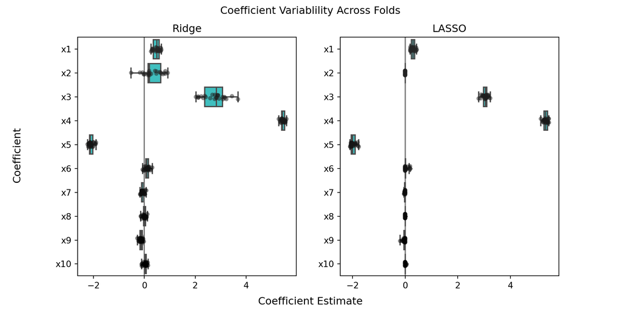

```python
from sklearn.model_selection import RepeatedKFold, cross_validate

# determine alphas for cross validation
alphas = np.logspace(-5, 5, 100)

# create cross-validation object with 5 folds and 5 repeats
cv = RepeatedKFold(n_splits=5, n_repeats=5, random_state=0)

# make ridgeCV model and perform cross validation using Q4 function
pipeline_ridge = make_pipe(preprocessor, RidgeCV(alphas = alphas))
# cross_validate does transforming and fitting for us
cv_model_ridge = cross_validate(
    pipeline_ridge,
    X,
    y,
    cv=cv,
    return_estimator=True, # otherwise we wouldn't be able to extract coefs
    n_jobs=1,
)

# do the same for the LASSO
pipeline_lasso = make_pipe(preprocessor, LassoCV(alphas = alphas))
cv_model_lasso = cross_validate(
    pipeline_lasso,
    X,
    y,
    cv=cv,
    return_estimator=True, # otherwise we wouldn't be able to extract coefs
    n_jobs=1,
)

# get feature names for data frame
feature_names = pipeline_ridge['preprocess'].get_feature_names_out()

# make data frame of all 25 sets of ridge coefficient estimates
coefs_ridge = pd.DataFrame(
    [est[-1].coef_ for est in cv_model_ridge["estimator"]],
    columns = feature_names
)

# make data frame of all 25 sets of lasso coefficient estimates
coefs_lasso = pd.DataFrame(
    [est[-1].coef_ for est in cv_model_lasso["estimator"]],
    columns = feature_names
)

# plotting both side by side
fig, axes = plt.subplots(1, 2)
# two axes now because two subplots
ax0 = axes[0]
ax1 = axes[1]

# Ridge plot
sns.stripplot(data=coefs_ridge, orient="h", palette="dark:k", alpha=0.5, ax = ax0)
sns.boxplot(data=coefs_ridge, orient="h", color="cyan", saturation=0.5, whis=10, ax = ax0)
ax0.axvline(x=0, color=".5")
ax0.set(
  title = "Ridge"
)

# LASSO plot
sns.stripplot(data=coefs_lasso, orient="h", palette="dark:k", alpha=0.5, ax = ax1)
sns.boxplot(data=coefs_lasso, orient="h", color="cyan", saturation=0.5, whis=10, ax = ax1)
ax1.axvline(x=0, color=".5")
ax1.set(
  title = "LASSO"
)

# overall title
fig.suptitle("Coefficient Variablility Across Folds")
fig.supxlabel("Coefficient Estimate")
fig.supylabel("Coefficient")

plt.show()
```

```python
plt.clf()
```

The LASSO model seems to create more stable coefficient estimates across folds for `x2` and `x3`. This can be seen in comparing the boxplots, as the LASSO ones are smaller and thus have a smaller and more stable range of values.

# Part 2: Predicting Deforestation

```python
# import data sets
forest = pd.read_csv("data/forest.csv")
forest_area = pd.read_csv("data/forest_area.csv")
soybean_use = pd.read_csv("data/soybean_use.csv")
vegetable_oil = pd.read_csv("data/vegetable_oil.csv")
vdem = pd.read_csv("data/vdem_subset_hw3.csv")
```

## Q1

```python
# drop where code is NA
forest_area = forest_area[forest_area["code"].notnull()]
soybean_use = soybean_use[soybean_use["code"].notnull()]
vegetable_oil = vegetable_oil[vegetable_oil["code"].notnull()]

# turn e_regionpol_6c into categorical variable
vdem["e_regionpol_6C"] = vdem["e_regionpol_6C"].astype("category")
```

## Q2

```python
# pivot wider and switch entity, code, and year back to columns
vegetable_oil = vegetable_oil.pivot(index=["entity", "code", "year"], columns="crop_oil", values="production").reset_index(names=["entity", "code", "year"])

vegetable_oil.head()
```

```
crop_oil       entity code  year  ...  Sesame  Soybean  Sunflower
0         Afghanistan  AFG  1961  ...  2253.0      NaN     2938.0
1         Afghanistan  AFG  1962  ...  1876.0      NaN     3138.0
2         Afghanistan  AFG  1963  ...  1831.0      NaN     3138.0
3         Afghanistan  AFG  1964  ...  2722.0      NaN     3138.0
4         Afghanistan  AFG  1965  ...  2821.0      NaN     3238.0

[5 rows x 16 columns]
```

## Q3

```python
# make new data frame by merging all data sets together
# also merging on entity so i don't have duplicate columns
deforest = pd.merge(pd.merge(pd.merge(pd.merge(forest, forest_area, on = ["code", "year", "entity"]), soybean_use, on = ["code", "year", "entity"]), vegetable_oil, on = ["code", "year", "entity"]), vdem, left_on = ["code", "year"], right_on = ["country_text_id", "year"])

# create new variable
deforest["forest_change_per_sq_km"] = deforest["net_forest_conversion"] * 100 / deforest["e_area"]

deforest.head()
```

```
      entity code  year  ...       e_area  e_regionpol_6C  forest_change_per_sq_km
0    Algeria  DZA  1990  ...  2317487.621               3                -0.379722
1    Algeria  DZA  2000  ...  2317487.621               3                 1.462791
2    Algeria  DZA  2010  ...  2317487.621               3                 0.327941
3  Argentina  ARG  1990  ...  2780961.118               2                -6.566075
4  Argentina  ARG  2000  ...  2780961.118               2               -11.377362

[5 rows x 30 columns]
```

## Q4

```python
# drop columns where 70+% of values are non-NA
# then, drop rows with NA values
deforest = deforest.dropna(thresh = (len(deforest) * 0.7), axis = 1).dropna()

# make X
X = deforest.drop(["forest_area", "code", "entity", "e_area", "net_forest_conversion",
                   "country_name", "country_text_id", "forest_change_per_sq_km"], axis = 1)

# make country_years
country_years = deforest[["code", "entity", "year"]]

# make y
y = deforest["forest_change_per_sq_km"]
```

## Q5

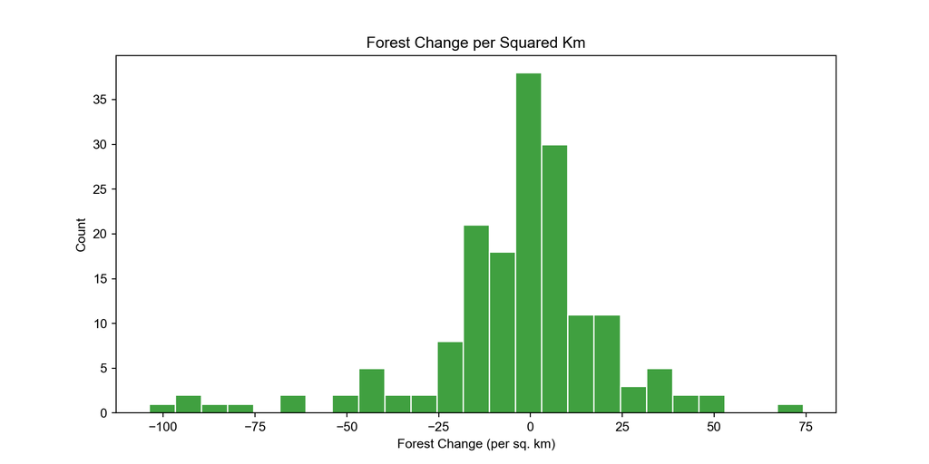

```python
fig, ax = plt.subplots()

# create histogram
sns.set_style("whitegrid")
sns.histplot(data = y, ax = ax, color = "green")
# set title and axis label
ax.set(title = "Forest Change per Squared Km", xlabel = "Forest Change (per sq. km)")

plt.show()
```

The histogram seems to be centered at 0. It follows a relatively normal shape, perhaps a bit skewed left. The spread seems to be relatively large, with values about 100 units (in $km^2$) away from the center. However, most values fall relatively close to the center.

## Q6

```python
grouped_cv = GroupKFold(n_splits = 10)
# split data
grouped_cv.split(X, y, groups = country_years["entity"])
```

```
<generator object _BaseKFold.split at 0x148692580>
```

## Q7

```python
# columns we want to use for StandardScaler()
num_cols = X.drop(["e_regionpol_6C"], axis=1).columns

transformer = make_column_transformer((OneHotEncoder(drop = "first"),
                                                     ["e_regionpol_6C"]),
                                      (StandardScaler(), num_cols),
                                      verbose_feature_names_out=False)

# make pipelines
pipeline_lin = make_pipe(transformer, LinearRegression())

pipeline_ridge_cv = make_pipe(transformer, RidgeCV(alphas = np.logspace(-5, 5, 100)))

pipeline_lasso_cv = make_pipe(transformer, LassoCV(alphas = np.logspace(-5, 5, 100), max_iter = 40000))
```

## Q8

```python
# cross validation model for linear
cv_lin = cross_validate(
    pipeline_lin,
    X,
    y,
    cv=grouped_cv,
    return_estimator=True, # otherwise we wouldn't be able to extract coefs
    n_jobs=1,
    groups=country_years["entity"],
    scoring="neg_mean_squared_error",
)


# cross validation model for Ridge
cv_ridge = cross_validate(
    pipeline_ridge_cv,
    X,
    y,
    cv=grouped_cv,
    return_estimator=True, # otherwise we wouldn't be able to extract coefs
    n_jobs=1,
    groups=country_years["entity"],
    scoring="neg_mean_squared_error",
)

# cross validation model for Ridge
cv_lasso = cross_validate(
    pipeline_lasso_cv,
    X,
    y,
    cv=grouped_cv,
    return_estimator=True, # otherwise we wouldn't be able to extract coefs
    n_jobs=1,
    groups=country_years["entity"],
    scoring="neg_mean_squared_error",
)
```

## Q9

```python
mse = pd.DataFrame(list(zip(cv_lin["test_score"], cv_ridge["test_score"], cv_lasso["test_score"])), columns = ["linear", "Ridge", "LASSO"])

mse
```

```
        linear        Ridge        LASSO
0 -5745.964282 -6690.844562 -4778.329690
1 -1965.133367 -1995.379609 -2372.232544
2  -935.395902  -964.044155 -1305.482719
3  -639.773716  -637.615033  -580.710202
4  -298.690182  -231.944865  -249.530717
5  -273.526555  -223.589421  -141.142057
6  -371.022583  -357.583020  -354.100292
7 -1011.245705 -1023.964570  -915.636160
8  -159.317153  -140.957108  -181.886770
9  -172.412546  -178.583321  -292.343098
```

```python
mse.mean(axis=0)
```

```
linear   -1157.248199
Ridge    -1244.450567
LASSO    -1117.139425
dtype: float64
```

Looking at the data frame with all MSEs for the three models (where the index is one less than the fold), the linear and Ridge models seem to perform pretty comparatively. The LASSO model seems to do better in about half of the folds, but worse in the other half. For example, the MSE is much smaller in folds 1, 4, 6, and 8, but worse in folds 2, 3 and 10. Averaging across all folds, LASSO tends to perform the best.

## Q10

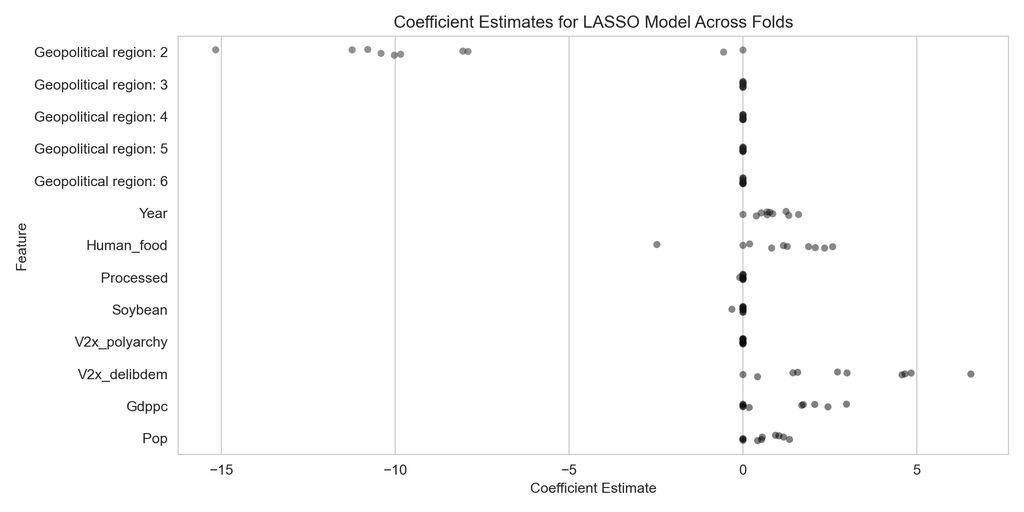

```python
# get coefficient values for each fold
coefs = [est["model"].coef_ for est in cv_lasso["estimator"]]

# get col names (coefficients) for data frame
cols = cv_lasso["estimator"][1]['preprocess'].get_feature_names_out()

# tidy up feature names
cols = [col.replace("e_regionpol_6C_", "Geopolitical Region: ") for col in cols.tolist()]
cols = [col.replace("e_", "") for col in cols]
cols = [col.capitalize() for col in cols]

# make data frame of all lasso coefficient estimates
coefs_lasso_cv = pd.DataFrame(coefs, columns = cols)

# turn data into strip plot
fig, ax = plt.subplots()

sns.stripplot(data = coefs_lasso_cv, orient="h", palette="dark:k", alpha=0.5, ax = ax)
ax.set(title = "Coefficient Estimates for LASSO Model Across Folds",
       xlabel = "Coefficient Estimate", ylabel = "Feature")

# called so Y-axis labels aren't cut off
plt.tight_layout()
plt.show()
```

```python
plt.clf()

# print out data frame to look at what coefficients zero'd out
coefs_lasso_cv
```

```
   Geopolitical region: 2  Geopolitical region: 3  ...     Gdppc       Pop
0              -11.239795                     0.0  ...  0.000000  0.000000
1               -0.000000                     0.0  ...  0.000000  0.000000
2               -0.557669                     0.0  ...  2.975541  1.035411
3               -8.055144                     0.0  ...  2.443520  1.337283
4               -9.844035                     0.0  ...  0.000000  0.536293
5               -7.907068                     0.0  ...  0.178347  0.422112
6              -10.406637                     0.0  ...  2.063787  1.166076
7              -15.162537                     0.0  ...  0.000000  0.555536
8              -10.025611                     0.0  ...  1.735045  0.000000
9              -10.789757                     0.0  ...  1.692293  0.935034

[10 rows x 13 columns]
```

Across the ten folds, the coefficients for the LASSO model do seem relatively stable. In the strip plot, the coefficients associated with `Geopolitical Region: 2` and `v2x_delibdem` seem to be the least stable, indicated by the wider spread of dots for those rows. `Geopolitical Region: 2` has coefficient estimates ranging in value by about 15, which is quite large. Looking at the table above, where each row is one fold, is an easy way to visualize the different estimates. In all ten folds, the coefficients associated with geopolitical regions 3-6 are all zero’d out, as well as `v2x_polyarchy`. Besides fold 1, the estimates for the `processed` feature are all zero, and besides fold 8, the estimates for the `soybean` predictor are all zero.